# Part I - Prosper Loan Dataset Exploration

## Introduction

> This data set contains 113,937 loans with 81 variables on each loan, including loan amount, borrower rate (or interest rate), current loan status, borrower income, and many others.

## Preliminary Wrangling

```python
# import all packages and set plots to be embedded inline
import numpy as np
import pandas as pd
import matplotlib.pyplot as plt
import seaborn as sb
%matplotlib inline

import warnings
warnings.filterwarnings('ignore')
```

```python
# reading the csv file into a dataframe named loan
loan = pd.read_csv('prosperLoanData.csv')
```

```python
# high-level overview of data shape and composition
print(loan.shape)
print(loan.dtypes)
print(loan.head(10))
```

```
(113937, 81)
ListingKey                              object
ListingNumber                            int64
ListingCreationDate                     object
CreditGrade                             object
Term                                     int64
LoanStatus                              object
ClosedDate                              object
BorrowerAPR                            float64
BorrowerRate                           float64
LenderYield                            float64
EstimatedEffectiveYield                float64
EstimatedLoss                          float64
EstimatedReturn                        float64
ProsperRating (numeric)                float64
ProsperRating (Alpha)                   object
ProsperScore                           float64
ListingCategory (numeric)                int64
BorrowerState                           object
Occupation                              object
EmploymentStatus                        object
EmploymentStatusDuration               float64
IsBorrowerHomeowner                       bool
CurrentlyInGroup                          bool
GroupKey                                object
DateCreditPulled                        object
CreditScoreRangeLower                  float64
CreditScoreRangeUpper                  float64
FirstRecordedCreditLine                 object
CurrentCreditLines                     float64
OpenCreditLines                        float64
                                        ...
TotalProsperLoans                      float64
TotalProsperPaymentsBilled             float64
OnTimeProsperPayments                  float64
ProsperPaymentsLessThanOneMonthLate    float64
ProsperPaymentsOneMonthPlusLate        float64
ProsperPrincipalBorrowed               float64
ProsperPrincipalOutstanding            float64
ScorexChangeAtTimeOfListing            float64
```

[output cut: 81 more lines]

```
9            1.0                0                          0

  InvestmentFromFriendsAmount Investors
0                         0.0       258
1                         0.0         1
2                         0.0        41
3                         0.0       158
4                         0.0        20
5                         0.0         1
6                         0.0         1
7                         0.0         1
8                         0.0         1
9                         0.0         1

[10 rows x 81 columns]
```

```python
#Selecting my columns of interest
loan_clean = loan[['ListingNumber', 'ListingCreationDate', 'CreditGrade','Term', 'LoanStatus', 'ClosedDate', 'BorrowerAPR',
             'BorrowerRate','LenderYield', 'ProsperRating (Alpha)','ProsperScore', 'ListingCategory (numeric)', 'BorrowerState',
            'Occupation', 'EmploymentStatus', 'CreditScoreRangeLower','DebtToIncomeRatio', 'IncomeRange', 'StatedMonthlyIncome','TotalProsperLoans',
             'LoanMonthsSinceOrigination', 'LoanOriginalAmount','LoanOriginationDate','MonthlyLoanPayment']]
loan_clean.head()
```

|  | ListingNumber | ListingCreationDate | CreditGrade | Term | LoanStatus | ClosedDate | BorrowerAPR | BorrowerRate | LenderYield | ProsperRating (Alpha) | ... | EmploymentStatus | CreditScoreRangeLower | DebtToIncomeRatio | IncomeRange | StatedMonthlyIncome | TotalProsperLoans | LoanMonthsSinceOrigination | LoanOriginalAmount | LoanOriginationDate | MonthlyLoanPayment |
| --- | --- | --- | --- | --- | --- | --- | --- | --- | --- | --- | --- | --- | --- | --- | --- | --- | --- | --- | --- | --- | --- |
| 0 | 193129 | 2007-08-26 19:09:29.263000000 | C | 36 | Completed | 2009-08-14 00:00:00 | 0.16516 | 0.1580 | 0.1380 | NaN | ... | Self-employed | 640.0 | 0.17 | $25,000-49,999 | 3083.333333 | NaN | 78 | 9425 | 2007-09-12 00:00:00 | 330.43 |
| 1 | 1209647 | 2014-02-27 08:28:07.900000000 | NaN | 36 | Current | NaN | 0.12016 | 0.0920 | 0.0820 | A | ... | Employed | 680.0 | 0.18 | $50,000-74,999 | 6125.000000 | NaN | 0 | 10000 | 2014-03-03 00:00:00 | 318.93 |
| 2 | 81716 | 2007-01-05 15:00:47.090000000 | HR | 36 | Completed | 2009-12-17 00:00:00 | 0.28269 | 0.2750 | 0.2400 | NaN | ... | Not available | 480.0 | 0.06 | Not displayed | 2083.333333 | NaN | 86 | 3001 | 2007-01-17 00:00:00 | 123.32 |
| 3 | 658116 | 2012-10-22 11:02:35.010000000 | NaN | 36 | Current | NaN | 0.12528 | 0.0974 | 0.0874 | A | ... | Employed | 800.0 | 0.15 | $25,000-49,999 | 2875.000000 | NaN | 16 | 10000 | 2012-11-01 00:00:00 | 321.45 |
| 4 | 909464 | 2013-09-14 18:38:39.097000000 | NaN | 36 | Current | NaN | 0.24614 | 0.2085 | 0.1985 | D | ... | Employed | 680.0 | 0.26 | $100,000+ | 9583.333333 | 1.0 | 6 | 15000 | 2013-09-20 00:00:00 | 563.97 |

5 rows × 24 columns

```python
#replacing  variable names for consistency
loan_clean['IncomeRange'] = loan_clean['IncomeRange'].replace({'Not displayed':np.nan,'Not employed':'$0'})
```

```python
# converting the data type for the date column to date data type
loan_clean["ListingCreationDate"] = pd.to_datetime(loan_clean['ListingCreationDate']).dt.date
loan_clean["ClosedDate"] = pd.to_datetime(loan_clean["ClosedDate"]).dt.date
loan_clean['LoanOriginationDate'] = pd.to_datetime(loan_clean['LoanOriginationDate']).dt.date
```

```python
#identify the rows with duplicate entries and drop it
print(loan_clean['ListingNumber'].duplicated().sum())
loan_clean['ListingNumber'].drop_duplicates(inplace=True)
```

```
871
```

```python
'''The function below combines the Credit Grade column and the prosper rating column into a single column to account for the
        credit grade before 2009 and after 2009 '''

col = ['CreditGrade','ProsperRating (Alpha)']
def join_all(x):
    return ','.join(x.dropna().astype(str))
loan_clean['Credit_rating']  = loan_clean[col].apply(join_all,axis=1)
loan_clean['Credit_rating'].replace({'':np.nan},inplace=True)
```

```python
# convert IncomeRange, Credit rating into ordered categorical types
ordinal_var_dict = {'IncomeRange':['$0','$1-24,999','$25,000-49,999','$50,000-74,999','$75,000-99,999','$100,000+'],
                    'Credit_rating':['HR','E','D','C','B','A','AA']}

for var in ordinal_var_dict:
    ordered_var = pd.api.types.CategoricalDtype(ordered = True,
                                                categories = ordinal_var_dict[var])
    loan_clean[var] = loan_clean[var].astype(ordered_var)
```

```python
credit_range =['HR','E','D','C','B','A','AA']
```

```python
# replace the listing category with words instead of numbers for easy understanding
loan_clean['ListingCategory (numeric)'] = loan_clean['ListingCategory (numeric)'].astype(str)
loan_clean['ListingCategory (numeric)'] = loan_clean['ListingCategory (numeric)'].replace({ '0' : np.nan , '1' : 'Debt Consolidation', '2' : 'Home Improvement', '3' : 'Business',
                                                                     '4' : 'Personal Loan', '5' : 'Student Use', '6' : 'Auto', '7' : 'Other', '8' : 'Baby&Adoption', '9' : 'Boat',
                                                                    '10' : 'Cosmetic Procedure', '11' : 'Engagement Ring', '12' : 'Green Loans', '13' : 'Household Expenses',
                                                                    '14' : 'Large Purchases', '15' : 'Medical/Dental', '16' : 'Motorcycle',
                                                                     '17' : 'RV', '18' : 'Taxes', '19' : 'Vacation', '20' : 'Wedding Loans'})
```

```python
#renaming column names and replacing variables to ensure consistency
loan_clean['Credit_rating'].replace({'NC':np.nan},inplace=True)
loan_clean.EmploymentStatus.replace({'Full-time':'Employed','Not available':np.nan},inplace=True)
loan_clean.rename({'ListingCategory (numeric)':'ListingCategory'},inplace=True)
```

```python
# since no one can have a credit score of Zero https://www.nerdwallet.com/article/finance/no-credit-score-zero-credit-score
loan_clean.CreditScoreRangeLower.replace({0:np.nan},inplace=True)
```

```python
bin_edges = [300,630,680,720,880 ]

# name of each credit score level
bin_names = ['Bad','Fair','Good','Excellent']

loan_clean['CreditScore_levels'] = pd.cut(loan_clean['CreditScoreRangeLower'], bin_edges, labels=bin_names)

# Checking for successful creation of this column
loan_clean.head()
```

|  | ListingNumber | ListingCreationDate | CreditGrade | Term | LoanStatus | ClosedDate | BorrowerAPR | BorrowerRate | LenderYield | ProsperRating (Alpha) | ... | DebtToIncomeRatio | IncomeRange | StatedMonthlyIncome | TotalProsperLoans | LoanMonthsSinceOrigination | LoanOriginalAmount | LoanOriginationDate | MonthlyLoanPayment | Credit_rating | CreditScore_levels |
| --- | --- | --- | --- | --- | --- | --- | --- | --- | --- | --- | --- | --- | --- | --- | --- | --- | --- | --- | --- | --- | --- |
| 0 | 193129 | 2007-08-26 | C | 36 | Completed | 2009-08-14 | 0.16516 | 0.1580 | 0.1380 | NaN | ... | 0.17 | $25,000-49,999 | 3083.333333 | NaN | 78 | 9425 | 2007-09-12 | 330.43 | C | Fair |
| 1 | 1209647 | 2014-02-27 | NaN | 36 | Current | NaT | 0.12016 | 0.0920 | 0.0820 | A | ... | 0.18 | $50,000-74,999 | 6125.000000 | NaN | 0 | 10000 | 2014-03-03 | 318.93 | A | Fair |
| 2 | 81716 | 2007-01-05 | HR | 36 | Completed | 2009-12-17 | 0.28269 | 0.2750 | 0.2400 | NaN | ... | 0.06 | NaN | 2083.333333 | NaN | 86 | 3001 | 2007-01-17 | 123.32 | HR | Bad |
| 3 | 658116 | 2012-10-22 | NaN | 36 | Current | NaT | 0.12528 | 0.0974 | 0.0874 | A | ... | 0.15 | $25,000-49,999 | 2875.000000 | NaN | 16 | 10000 | 2012-11-01 | 321.45 | A | Excellent |
| 4 | 909464 | 2013-09-14 | NaN | 36 | Current | NaT | 0.24614 | 0.2085 | 0.1985 | D | ... | 0.26 | $100,000+ | 9583.333333 | 1.0 | 6 | 15000 | 2013-09-20 | 563.97 | D | Fair |

5 rows × 26 columns

```python
# creating different colour codes
base_color2 = sb.color_palette()[1]
base_color3 = sb.color_palette()[2]
```

### What is the structure of your dataset?

> There are 113937 Loan Entries in the dataset with 81 features (CreditGrade,Term, LoanStatus, ClosedDate, BorrowerAPR, BorrowerRate,LenderYield,ProsperRating (Alpha),ProsperScore, ListingCategory (numeric), BorrowerState and many more). Most variables are numeric in nature, but the variables ProsperScore, CreditGrade, and IncomeRange are ordered. (worst) ——> (best)
> - \$0 < \\$1-24,999 < \$25,000-49,999 < \\$50,000-74,999 < \$75,000-99,999 < \\$100,000+
> - HR < E < D < C < B < A < AA

### What is/are the main feature(s) of interest in your dataset?

> I'm interested in figuring out what features are best for predicting the Loan Amount of the Loans in the dataset.

### What features in the dataset do you think will help support your investigation into your feature(s) of interest?

- LoanOriginal Amount: CreditScoreLower,Term,MonthlyLoanPayment,StatedMonthlyIncome,IncomeRange,Listing_category,Borrowers APR,Is Borrower A home owner,Employment status,Debt to income ratio, borrower rate

## Univariate Exploration

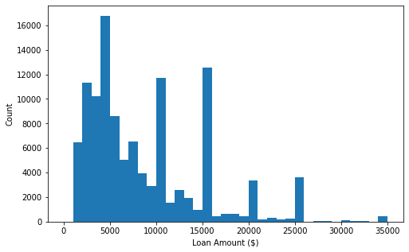

```python
binsize = 1000
bins = np.arange(0, loan_clean['LoanOriginalAmount'].max()+binsize, binsize)

plt.figure(figsize=[8, 5])
plt.hist(data = loan_clean, x = 'LoanOriginalAmount', bins = bins)
plt.xlabel('Loan Amount ($)')
plt.ylabel('Count');
```

The loan amount has a multimodal distibution and moost of the values fall be 3000 and 20000 and the peaks values are at 5000,10000,15000,20000 shows most loans are taken in the mutiples of 5000

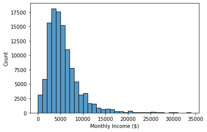

```python
bins = np.arange(0,35000,1000)
sb.histplot(data=loan_clean,x='StatedMonthlyIncome',bins=bins)
plt.xlabel('Monthly Income ($)');
```

The Above monthly income is a unimodal distribution that shows that most borrowers have a monthly income in the ranges of 2500 and $10,000.The distribution has a long tail

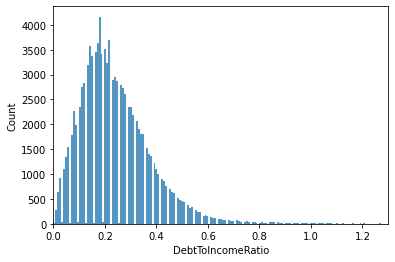

```python
bins = np.arange(0,1.3,0.01)
sb.histplot(data=loan_clean,x='DebtToIncomeRatio')
plt.xlim(0,1.3);
```

The Debt to income ratio is skewed, with the majority having a debt-to-income ratio of 0.1 to 0.4. With a peak value of around 0.2 showing that borrowers generally have a low debt-to-income ratio

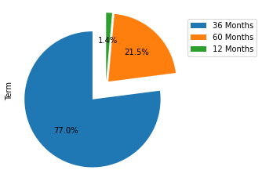

```python
explode =(0.3,0.05,0.05)
p1 =loan_clean['Term'].value_counts()/loan_clean['Term'].count()
p1.plot(kind='pie',autopct='%1.1f%%',labels=None,startangle=90,explode=explode)
plt.legend(['36 Months','60 Months','12 Months'],loc=(1,0.7))
plt.axis('square');
```

**77%** of the loans collected has a term of 36months, **21.5%** of the loan collected has lenght of 60 Months and a very small percentage of **1.4** has a term of 12 months

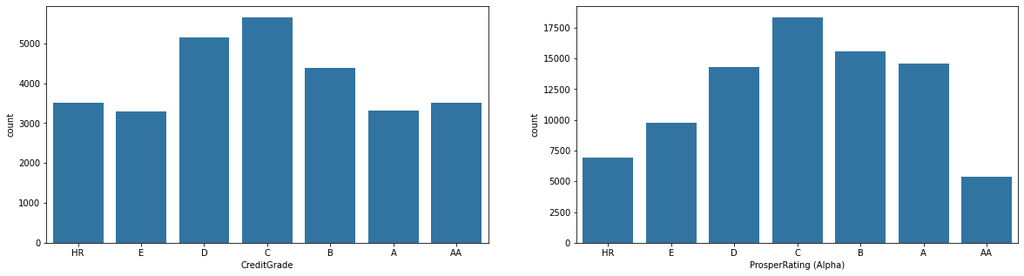

```python
base_color = sb.color_palette()[0]
plt.figure(figsize = [20, 5])
plt.subplot(1,2,1)
sb.countplot(data=loan_clean,x='CreditGrade',color=base_color,order=credit_range)
plt.subplot(1,2,2)
sb.countplot(data=loan_clean,x='ProsperRating (Alpha)',color=base_color,order=credit_range);
```

Most borrowers before 2009 have a credit grade of **C** and from 2009 the **C** has the highest prosper Rating count

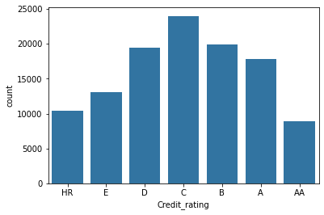

```python
# research shows NC means No credit so replacing it with null

sb.countplot(data=loan_clean,x='Credit_rating',color=base_color);
```

Afterthe prosper rating and the credit grades were joined together the above showed that most of the individuals who took loans had a Credit_rating of **C** . Majority had a credit rating between **D** and **A**

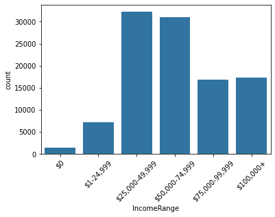

```python
sb.countplot(data=loan_clean,x='IncomeRange',color=base_color)
plt.xticks(rotation=45);
```

The above bar chart shows that most of the individuals who take loans fall between the income range of 25k-75k and those within the income range of \$0 are the lowest amount of people who requested for Loans

```python
prp_sc = loan_clean.loc[~loan_clean.ProsperScore.isnull()]
prp_sc.ProsperScore = prp_sc.ProsperScore.astype(int).astype(str)
prp_sc =prp_sc[prp_sc.ProsperScore!='11']
```

```python
score_scale = ['1', '2', '3', '4', '5', '6', '7', '8', '9', '10']
scores  = pd.api.types.CategoricalDtype(ordered=True,categories=score_scale)
prp_sc.ProsperScore = prp_sc.ProsperScore.astype(scores)
```

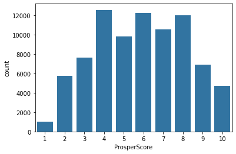

```python
sb.countplot(data=prp_sc,x='ProsperScore',color=base_color);
```

The bar chart above shows just very few people have a score of 1 who are considered to be of high risk . Most borrowers have a prosper score between 4-8 with 10 being of the lowest risk

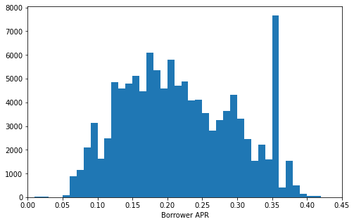

```python
bins = np.arange(0, loan_clean.BorrowerAPR.max()+0.05, 0.01)
plt.figure(figsize=[8, 5])
plt.hist(data = loan_clean, x = 'BorrowerAPR', bins = bins);
plt.xlabel('Borrower APR')
plt.xlim(0,0.45);
```

The Borrower APR has a multimodal distribution with most of its values betwwen 0.1 and 0.37. With its highest peak at 0.35

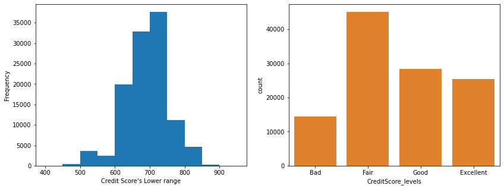

```python
plt.figure(figsize=(14,5))
plt.subplot(1,2,1)
bins= np.arange(400,1000,50)
plt.hist(data=loan_clean, x='CreditScoreRangeLower',bins=bins)
plt.xlabel("Credit Score's Lower range")
plt.ylabel('Frequency')
plt.subplot(1,2,2)
sb.countplot(x='CreditScore_levels',data=loan_clean,color=base_color2);
```

The distribution is unimodal with its peak between the 700 and 750 and most of the credit score range between 600-750 and most borrowers have a creditScore level of Fair and good

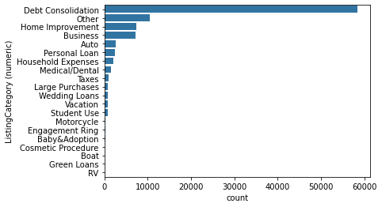

```python
play =loan_clean['ListingCategory (numeric)'].value_counts()

order = play.index

sb.countplot(data=loan_clean,y='ListingCategory (numeric)',order=order,color=base_color);
```

Visualization of the Listing category above shows that most people collect loans to consilidate a debt and The chances for a loan to be collected for an RV Purchase is very low

```python
loan_clean['Occupation']=loan_clean['Occupation'].str.split('-').str[0].str.strip()
```

```python
#i selected this occupation of interest
loan_clean_occupation = loan_clean.loc[loan_clean.Occupation.isin(['Professional', 'Executive', 'Accountant/CPA', 'Engineer', 'Sales','Computer Programmer','Student','Teacher','Analyst','Skilled Labor '])]
```

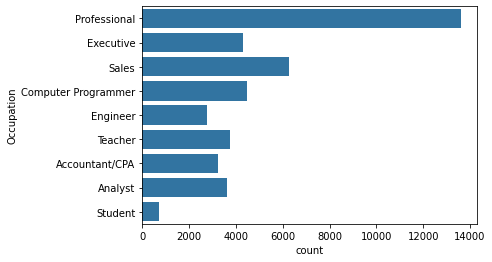

```python
sb.countplot(data=loan_clean_occupation,y='Occupation',color=base_color)
```

Professionals makes the most request for loans followed by people in sales the proportion of students who make request for loans are low

```python
loan_clean_state= loan_clean.loc[loan_clean.BorrowerState.isin(['CA', 'TX', 'NY', 'FL', 'IL','ND','ME','WY','IA','SD'])]
```

```python
#Selecting the top 5 Borrowers State
loan_clean_state1 = loan_clean.loc[loan_clean.BorrowerState.isin(['ND','ME','WY','IA','SD'])]
loan_clean_state2 = loan_clean.loc[loan_clean.BorrowerState.isin(['CA','TX','NY','FL','IL'])]
```

```python
state1 = ['SD','IA','WY','ME','ND']
state2=['CA', 'TX', 'NY', 'FL', 'IL']
```

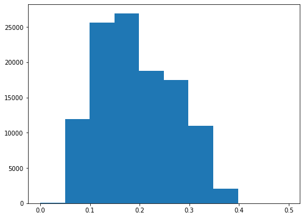

```python
plt.figure(figsize=(8,6))
plt.hist(data=loan_clean,x='BorrowerRate');
```

The distribution is unimodal with it's peak 0.15 and 0.2 and majority of the values fall between 0.1 and 0.3

[figure not shown]

```python
plt.figure(figsize=(14,5))
plt.subplot(1,2,2)
sb.countplot(data=loan_clean_state1,x='BorrowerState',order=state1,color=base_color2)
plt.xlabel('Five states with the Most Borrowers')
plt.subplot(1,2,1)
sb.countplot(data=loan_clean_state2,x='BorrowerState',order=state2,color=base_color3)
plt.xlabel('Five states with the Lowest Borrower Count');
```

The states with the most borrowers are CA,TX,NY,FL,IL, and the states with the least borrowers are SD, IA,WY,ME,ND

### Discuss the distribution(s) of your variable(s) of interest. Were there any unusual points? Did you need to perform any transformations?

> The loan original amount is a multimodal distribution with peaks at \$5000,10000,15000,20000,25000 which shows most loan were mutiples of 5000 and majority of borrower requested for within the range of 4000-15000 and very few borrowers took loans above 25000. No transformation was performed only the bin size was changed.

### Of the features you investigated, were there any unusual distributions? Did you perform any operations on the data to tidy, adjust, or change the form of the data? If so, why did you do this?

- The monthly income was unimodal with a long tail in which most borrowers earned between 2000 and 10,000 dollars a month
- NC in the credit range was found to mean No crdit which was changed to Null
- The credit range and the prosper Rating alpha columns were merged to create a single column for loans before 2009 and loans after 2009 and the Credit Range of C has the highest range
- some variables in the income range were combined for tidiness
- Debt to income ratio is right skewed
- The Borrower APR xlim was set to have a fixed focus on the major distribution
- The states with the most borrowers are CA,TX,NY,FL,IL, and the states with the least borrowers are SD, IA,WY,ME,ND
- The distribution is unimodal with it's peak 0.15 and 0.2 and majority of the values fall between 0.1 and 0.3

## Bivariate Exploration

> To start off with, I want to look at the pairwise correlations present between features in the data.

```python
loan_clean_sub = loan_clean.loc[loan_clean.LoanStatus.isin(['Current','Completed','Chargedoff','Defaulted'])]
```

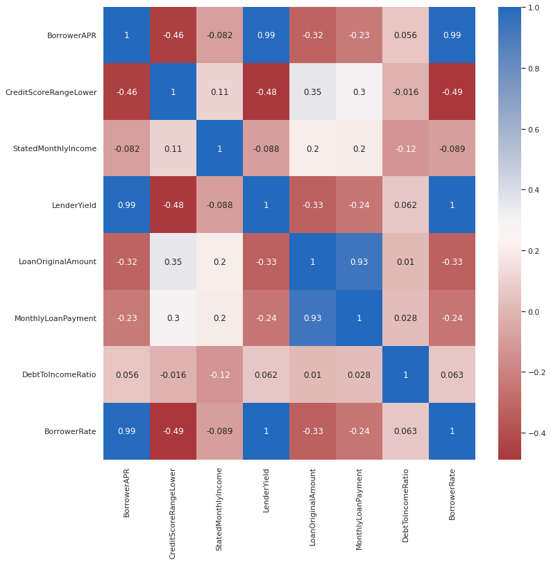

```python
numeric_var =['BorrowerAPR','CreditScoreRangeLower','StatedMonthlyIncome','LenderYield','LoanOriginalAmount','MonthlyLoanPayment','DebtToIncomeRatio','BorrowerRate']
loan_corr  = loan_clean[['BorrowerAPR','CreditScoreRangeLower','StatedMonthlyIncome','LenderYield','LoanOriginalAmount','MonthlyLoanPayment','DebtToIncomeRatio','BorrowerRate']]
sb.set(rc={'figure.figsize':(12,12)})
sb.heatmap(data=loan_corr.corr(),annot=True,cmap='vlag_r');
```

[output not shown]

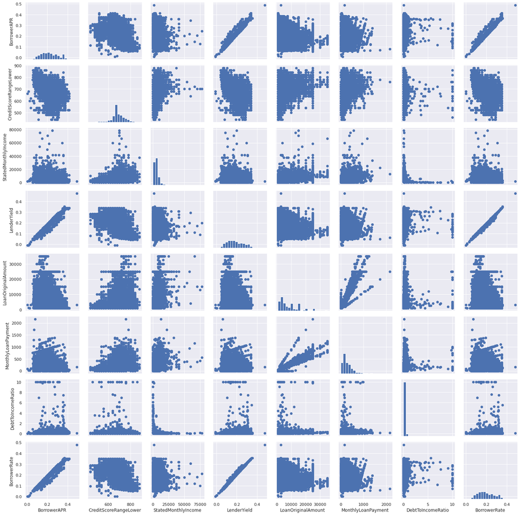

```python
# plot matrix: sample 500 diamonds so that plots are clearer and they render faster
print("loan.shape=",loan_corr.shape)
loan_samp = loan_corr.sample(n=10000, replace = False)
print("Loan_samp.shape=",loan_samp.shape)

g = sb.PairGrid(data = loan_samp, vars = numeric_var)
g = g.map_diag(plt.hist, bins = 20);
g.map_offdiag(plt.scatter);
```

- There is a strong postive correlation between the BorrowerRate,BorrowerApr and lender yield meaning an increase in any value would increase the value of the other.
- As expected the Loan amount has a strong Positive correlation correlation with the Monthly loan payment.
- Loan amount ,creditscorelowerrange,MonthlyLoanPayment all have a negative correlation with BorrowerRate,BorrowerApr and lender yield

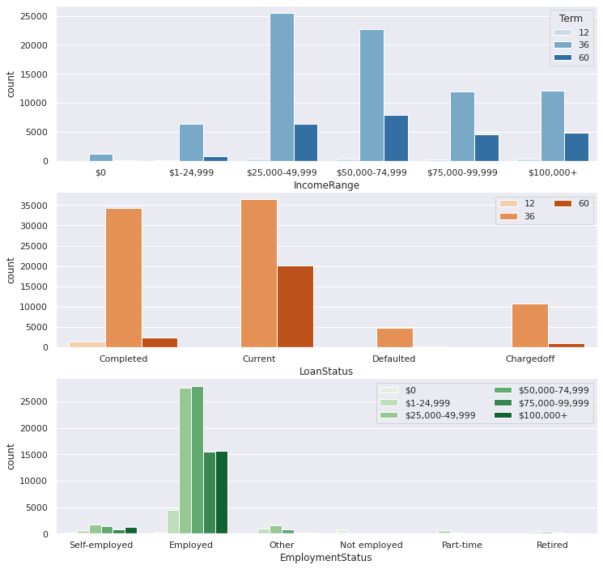

```python
plt.figure(figsize = [12, 12])

# subplot 1: Income Range Vs Term
plt.subplot(3, 1, 1)
sb.countplot(data = loan_clean, x = 'IncomeRange', hue = 'Term', palette = 'Blues')

# subplot 2: clarity vs. cut
ax = plt.subplot(3, 1, 2)
sb.countplot(data =loan_clean_sub , x = 'LoanStatus', hue = 'Term', palette = 'Oranges')
ax.legend(ncol = 2) # re-arrange legend to reduce overlapping

# subplot 3: clarity vs. color, use different color palette
ax = plt.subplot(3, 1, 3)
sb.countplot(data =loan_clean_sub, x = 'EmploymentStatus', hue = 'IncomeRange', palette = 'Greens')
ax.legend(loc = 1, ncol = 2);# re-arrange legend to remove overlapping
```

- The incomeRange and term clustered bar chart reveals that the 36 month is the commonest term amongst the three terms with the Income range of 25k-74.99k having the heigst count of both 36 and 60 month term
- Among the people whose loan status is defaulted no one has 12 month and 60month term loan while majority of the current loan has a 36month term and the current loan status has the number of 60 months loan term
- As expectedd those who are unemployed do not fall under any income range and those who are employed make up for majority of the borrowers within all income Ranges except the zero dollar income rnage which has a count of zero

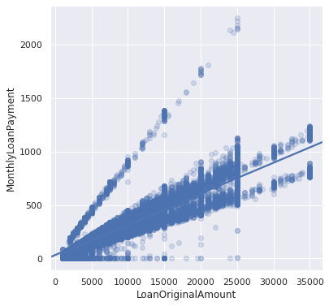

```python
plt.figure(figsize = [6, 6])
sb.regplot(data=loan_clean,y='MonthlyLoanPayment',x='LoanOriginalAmount',truncate=False, x_jitter=0.1, scatter_kws={'alpha':1/5})
```

The Loan amount and the monthly payment have a linear relationship meaning the higher the amount borrowed the Higher the monthly payment made

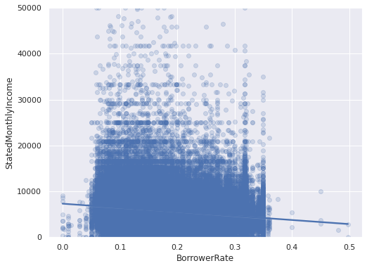

```python
plt.figure(figsize = [8, 6])
sb.regplot(data=loan_clean,x='BorrowerRate', y='StatedMonthlyIncome',scatter_kws={'alpha':1/5})
plt.ylim(0,50000);
```

There is a negative correalation between the Stated monthly income and BorrowerRate although small.

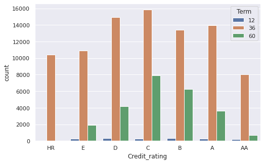

```python
plt.figure(figsize = [8, 5])
sb.countplot(data = loan_clean, x = 'Credit_rating', hue = 'Term');
```

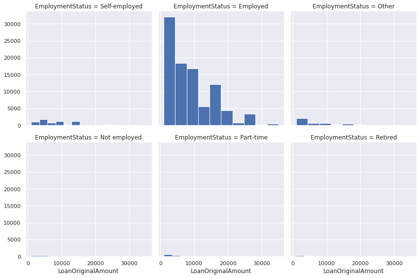

```python
g = sb.FacetGrid(data = loan_clean, col = 'EmploymentStatus',col_wrap=3,size=4)
g.map(plt.hist, "LoanOriginalAmount")
```

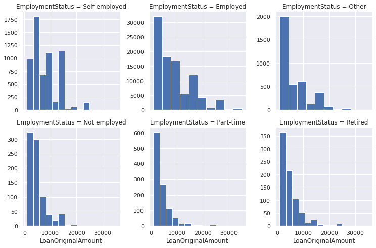

```python
g = sb.FacetGrid(data = loan_clean, col = 'EmploymentStatus',col_wrap=3,size=3.5,sharey=False)
g.map(plt.hist, "LoanOriginalAmount")
```

All Employment status gave us a right skewed Loan original Amount distribution.

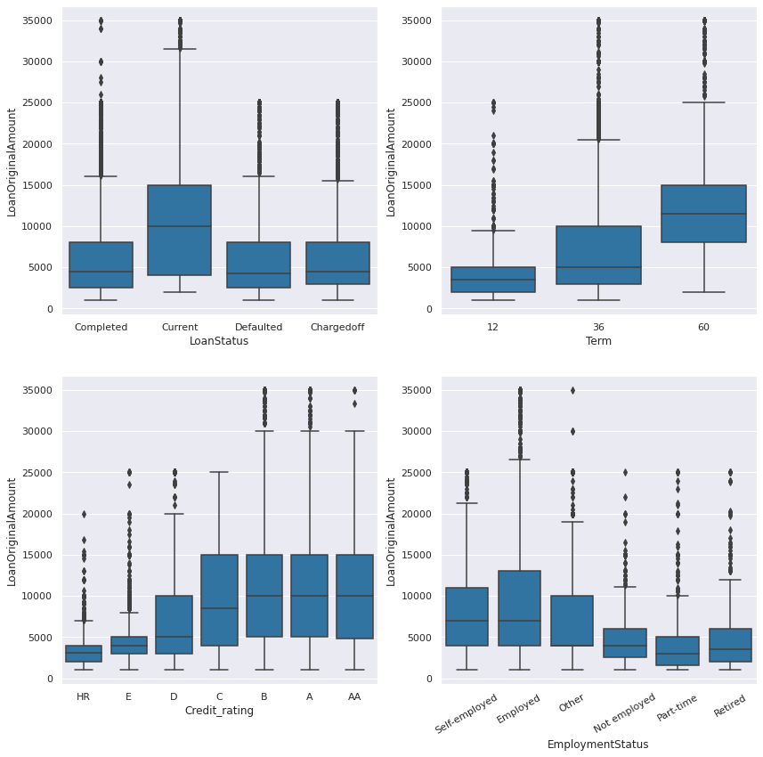

```python
plt.figure(figsize = [14,14])
plt.subplot(2,2,1)
sb.boxplot(data=loan_clean_sub,x='LoanStatus',y='LoanOriginalAmount',color=base_color)
plt.subplot(2,2,2)
sb.boxplot(data=loan_clean_sub,x='Term',y='LoanOriginalAmount',color=base_color)
plt.subplot(2,2,3)
sb.boxplot(data=loan_clean_sub,x='Credit_rating',y='LoanOriginalAmount',color=base_color)
plt.subplot(2,2,4)
sb.boxplot(data=loan_clean_sub,x='EmploymentStatus',y='LoanOriginalAmount',color=base_color)
plt.xticks(rotation=30);
```

- Looking at the box plot of employment status and loan origination amount for those in the "other" group seem to have no median values
- there seems to be a positive relationship between the loan original amount an the term and credit rating

```python
emp1 =loan_clean[loan_clean.EmploymentStatus=='Other']
emp1.describe()['LoanOriginalAmount']
```

```
count     3806.000000
mean      6861.727010
std       4854.981062
min       1000.000000
25%       4000.000000
50%       4000.000000
75%      10000.000000
max      35000.000000
Name: LoanOriginalAmount, dtype: float64
```

it has a median but the median has the same value with the Q1 (25th Percentile)

```python
# to calculate the average loan amount given out every year
yearly_amount  = loan_clean [['LoanOriginalAmount','LoanOriginationDate','MonthlyLoanPayment','StatedMonthlyIncome']]

yearly_amount['LoanOriginationYear']  = pd.to_datetime(yearly_amount['LoanOriginationDate']).dt.year
df1 = yearly_amount.groupby(by='LoanOriginationYear').mean()
df1['YearLoanPayment'] = df1['MonthlyLoanPayment'] *12
x =df1.index
df1.head()
```

| LoanOriginationYear | LoanOriginalAmount | MonthlyLoanPayment | StatedMonthlyIncome | YearLoanPayment |
| --- | --- | --- | --- | --- |
| 2005 | 3576.681818 | 102.434091 | 11123.106061 | 1229.209091 |
| 2006 | 4763.325262 | 168.256068 | 4743.658158 | 2019.072821 |
| 2007 | 7049.545026 | 247.308673 | 4654.253389 | 2967.704073 |
| 2008 | 6021.628289 | 209.800160 | 4618.913846 | 2517.601922 |
| 2009 | 4354.858818 | 155.009306 | 5091.736199 | 1860.111676 |

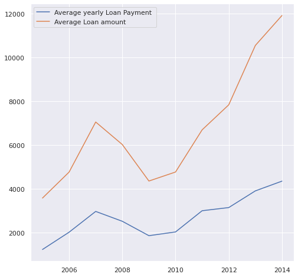

```python
plt.figure(figsize = [8, 8])
plt.plot( x, df1['YearLoanPayment'],label='Average yearly Loan Payment ')
plt.plot( x, df1['LoanOriginalAmount'], label='Average Loan amount')
plt.legend()
```

There was a rise in the loan amount requested by borrowers up till 2007, then a sharp decline in the loan amount till 2009 then a sharp, steady increase in Average loan Amount between 2010 and 2014 The average original loan amount by year is greater than the average Yearly loan payment made each year, with a decline between 2007 and 2009

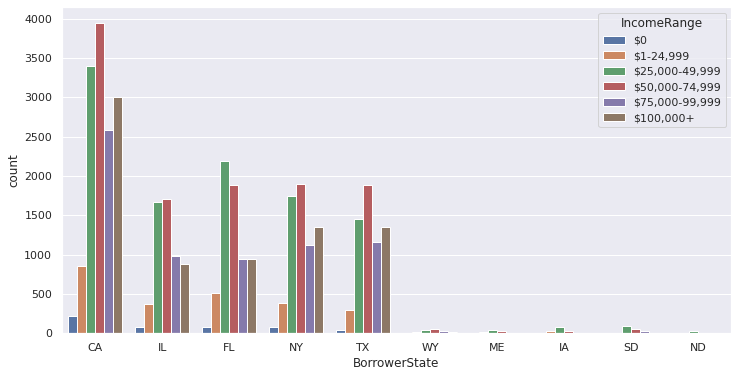

```python
plt.figure(figsize = [12, 6])
sb.countplot(data = loan_clean_state, x = 'BorrowerState', hue = 'IncomeRange');
```

This plot shows the top 5 states that borrowers are from and the least 5 states with borrowers CA has the heighest number of people across all income ranges with ND having the least across all income ranges . I want to investigate if this would affect the loan amount requested by state

```python
#finding the average income paid by state
df =loan_clean_state.groupby(by='BorrowerState').mean()[['LoanOriginalAmount','StatedMonthlyIncome']]
df.reset_index(inplace=True)
df.head()
```

|  | BorrowerState | LoanOriginalAmount | StatedMonthlyIncome |
| --- | --- | --- | --- |
| 0 | CA | 8974.325814 | 6184.829239 |
| 1 | FL | 8207.460565 | 5399.216319 |
| 2 | IA | 5601.919355 | 3714.396953 |
| 3 | IL | 8395.930924 | 5590.820343 |
| 4 | ME | 4849.584158 | 3635.320132 |

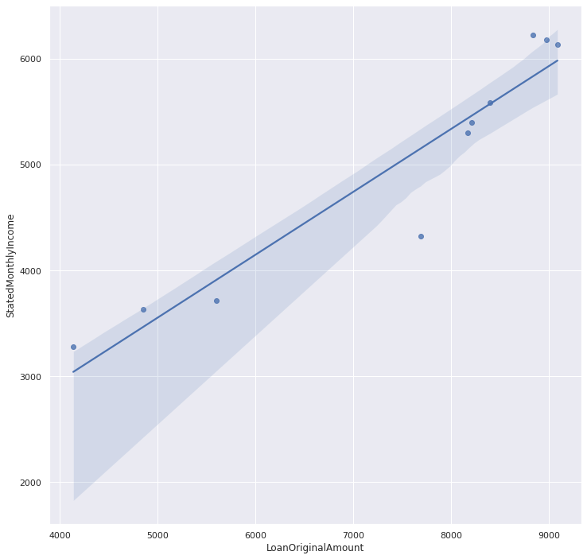

```python
sb.regplot(data=df,x='LoanOriginalAmount',y='StatedMonthlyIncome');
```

This satisfies my suggestion before that there is a strong positive correlation between income and loan Amount the higher the income of a borrower the higher the Loan Amount he can borrow

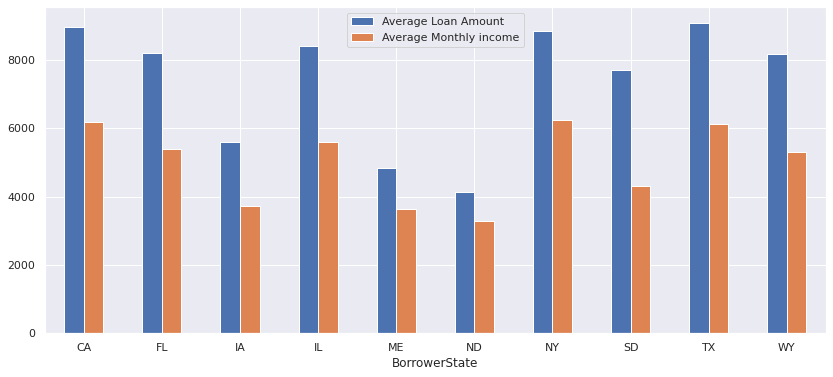

```python
df.plot(x="BorrowerState", y=["LoanOriginalAmount", "StatedMonthlyIncome"], kind="bar",figsize=(14,6))
plt.legend(['Average Loan Amount','Average Monthly income'])
plt.xticks(rotation=360);
```

The bar chart shows that higher loan amounts means a higher average monthly income

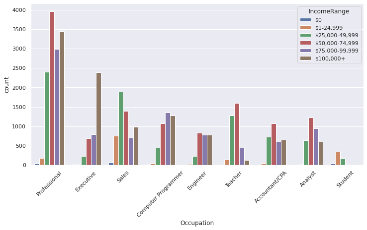

```python
plt.figure(figsize = [12, 6])
sb.countplot(data = loan_clean_occupation, x = 'Occupation', hue = 'IncomeRange')
plt.xticks(rotation=45);
```

As expected, no student has an income range exceeding 50,000, very few earn above 25,0000 and majority of executives earn above 100k, and no executive has a \$0 income range as expected, but surprisingly people who are professionals or in sales claim to have an income range of \\$0

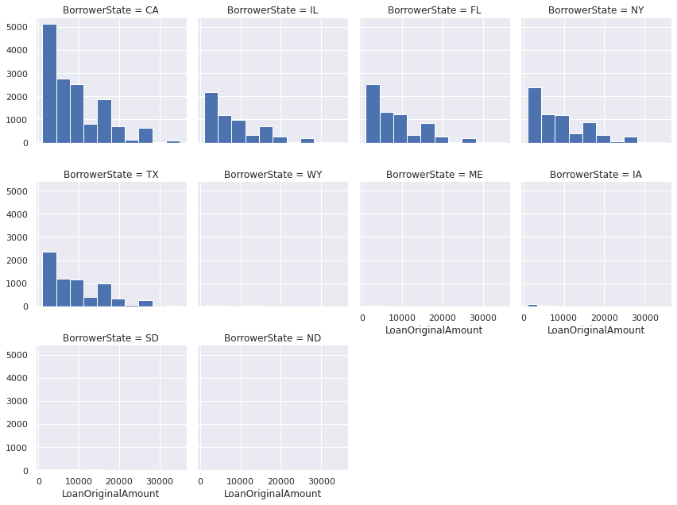

```python
g = sb.FacetGrid(data = loan_clean_state, col = 'BorrowerState',col_wrap=4)
g.map(plt.hist, "LoanOriginalAmount")
```

But what is consistent in each state is that the loan Amounts are right-skewed, with most borrowers requesting loans of less than 15000 dollars, and in states like ME, ND, and SD, the number of people who requested loans tends to look like zero except. I plan to change the shared axis to see a better count of the count of people and the loan amount a borrower requested

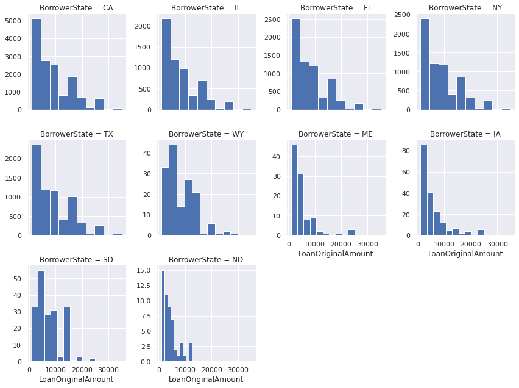

```python
g = sb.FacetGrid(data = loan_clean_state, col = 'BorrowerState',col_wrap=4,sharey=False)
g.map(plt.hist, "LoanOriginalAmount")
```

```python
loan_clean_credit =loan_clean.groupby(by='CreditScore_levels').mean()
loan_clean_credit.reset_index(inplace=True)
```

```python
loan_clean_credit
```

|  | CreditScore_levels | ListingNumber | Term | BorrowerAPR | BorrowerRate | LenderYield | ProsperScore | CreditScoreRangeLower | DebtToIncomeRatio | StatedMonthlyIncome | TotalProsperLoans | LoanMonthsSinceOrigination | LoanOriginalAmount | MonthlyLoanPayment |
| --- | --- | --- | --- | --- | --- | --- | --- | --- | --- | --- | --- | --- | --- | --- |
| 0 | Bad | 255734.954186 | 36.724698 | 0.264232 | 0.245648 | 0.234148 | 4.360936 | 576.899903 | 0.305961 | 4037.090483 | 1.358717 | 69.819797 | 3866.762044 | 145.855291 |
| 1 | Fair | 698965.907961 | 40.791797 | 0.245589 | 0.215586 | 0.205479 | 5.315559 | 661.905586 | 0.270237 | 5359.427544 | 1.441121 | 25.768782 | 7498.628937 | 256.341863 |
| 2 | Good | 724746.400120 | 42.439952 | 0.207188 | 0.179322 | 0.169407 | 5.971230 | 709.102627 | 0.292549 | 5955.332356 | 1.431660 | 22.581073 | 9850.510425 | 313.147053 |
| 3 | Excellent | 622125.541647 | 41.566493 | 0.159302 | 0.137640 | 0.128301 | 7.277650 | 766.595678 | 0.253682 | 6559.694550 | 1.417190 | 29.883381 | 10780.306436 | 330.855167 |

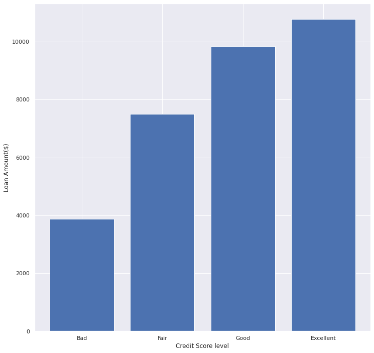

```python
plt.bar(data=loan_clean_credit,x='CreditScore_levels',height='LoanOriginalAmount')
plt.xlabel('Credit Score level')
plt.ylabel('Loan Amount($)');
```

The plot above shows that the better the credit score level the higher in the amount of loans you can take

### Talk about some of the relationships you observed in this part of the investigation. How did the feature(s) of interest vary with other features in the dataset?

Any interesting relationships between the other features (not the main feature(s) of interest)?

- The income range and term clustered bar chart reveals that the 36 month is the commonest term amongst the three terms, with the Income range of 25k-74.99k having the highest count of both 36 and a 60-month term
- Among the people whose loan status is defaulted, no one has 12 month and 60month term loan, while the majority of the current loan has a 36month term, and the current loan status has several 60 months loan term
- As expected, those who are unemployed do not fall under any income range, and those who are employed make up for the majority of the borrowers within all income Ranges except the zero dollar income range, which has a count of zero
- There is a strong positive correlation between the BorrowerRate, BorrowerApr and lender yield meaning an increase in any value would increase the value of the other.